# Team 3 R Plots

Vishekha, Vincent, Nishi and Malik

11/12/2019

# Overview

For this chunk of plots, a new cleaned dataset **“VH-Dataset-NWplot.csv”** had been created. This dataset contained data from 2013-2017 and only for North and West sites. The four plots below show the monthly differences in Turbudidy and Conductivity between North and West sites.

## Plot 1 and 2- Differences of Turbidity/Conductivity between the North and West sites (using geom line)

For these two plots, we are trying to look at the changes in Turbidity/Conductivity between the North and West sites. By using geom line, we can see the changes when the lines go up and down. We also faceted the plots based on the years to make sure that we are only comparing the monthly differences of a specific year. Finally, we distinguished the two sites with color.

To interpret these plots, we need to look at the specific month and see if the two lines are close to each other which means there is not much of a difference between the two sites. In a perfect world, we expect the two lines to lay over each other which means there are no differences. For instance, by looking at May 2013 of the first plot, we can tell that there is a big difference in measurements between the two sites.

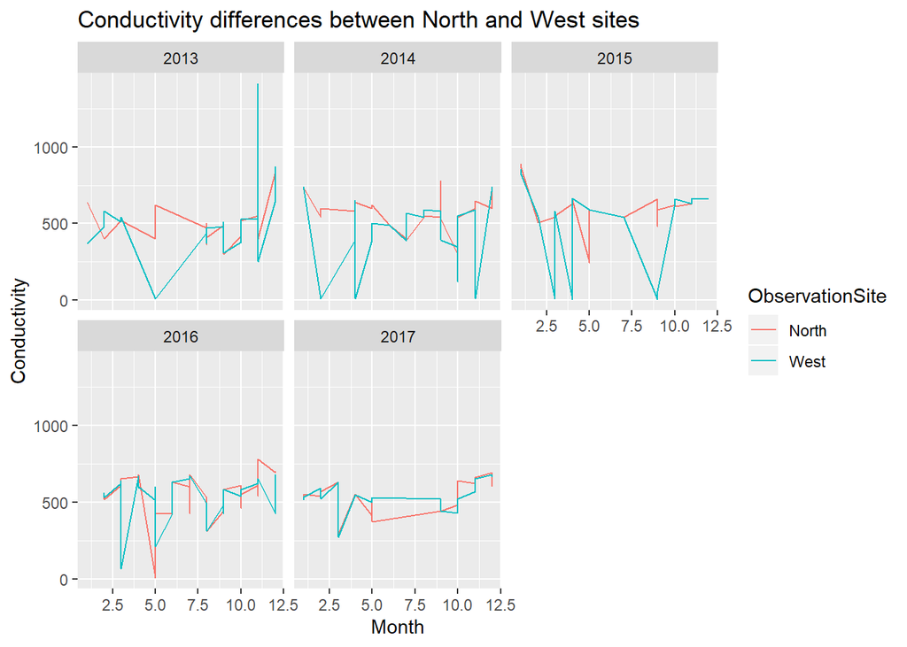

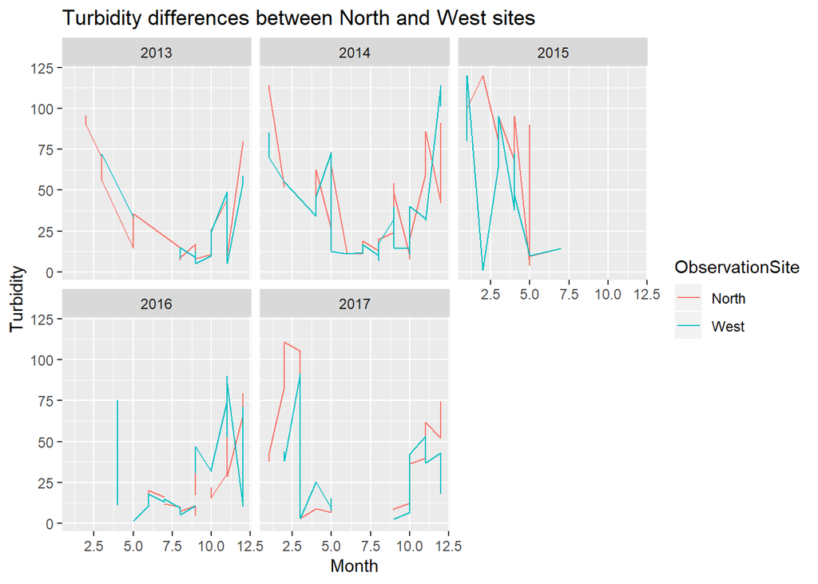

## Plot 3 and 4- Differences of Turbidity/Conductivity between the North and West sites (using geom point)

For these two plots, we are trying to look at the changes in Turbidity/Conductivity between the North and West sites. By using geom point, we can see the changes when the points go up and down. We also faceted the plots based on the years to make sure that we are only comparing the monthly differences of a specific year. Finally, we distinguished the two sites with color.

To interpret these plots, we need to look at the specific month and see if the clusters of points are close to each other which means there is not much of a difference between the two sites. In a perfect world, we expect the cluster of points to lay over each other which means there are no differences. For instance, by looking at September 2015 of the first plot, we can tell that there is a big difference in measurements between the two sites.

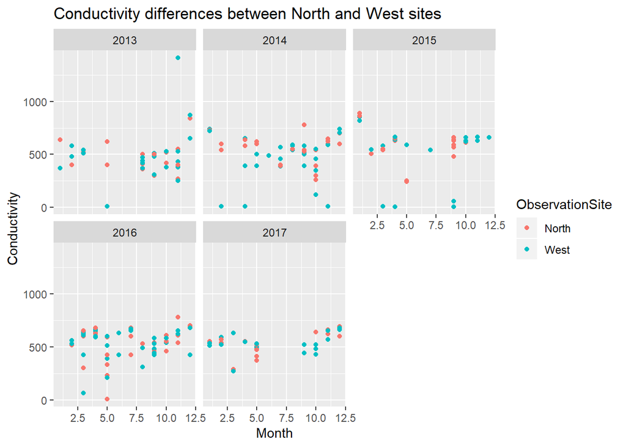

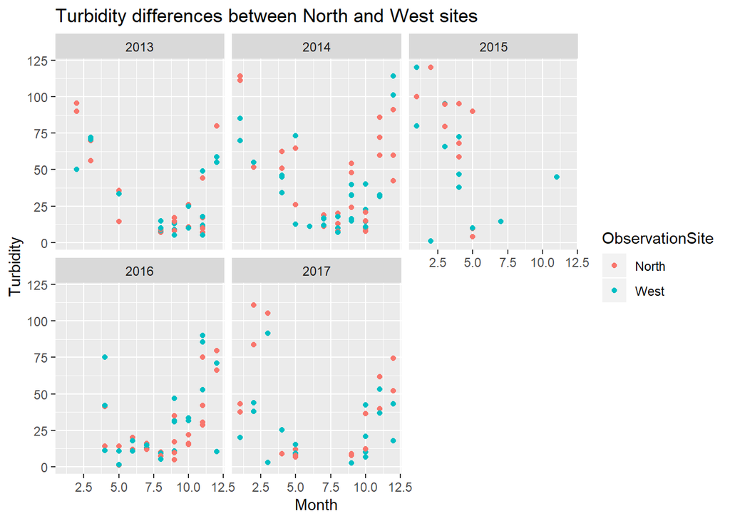

## Analysis By Creating R Plots for pH level of water with respect to Dissolved Oxygen and Alkalinity For North Site.

For the below plots, a new cleaned dataset **“North Site.csv”** was created. The dataset consists of data from 2013-2017 and observations belonging only for the North site.

We would look at the distribution for the variables Dissolved Oxygen, Alkanility and pH level of water for the North site.

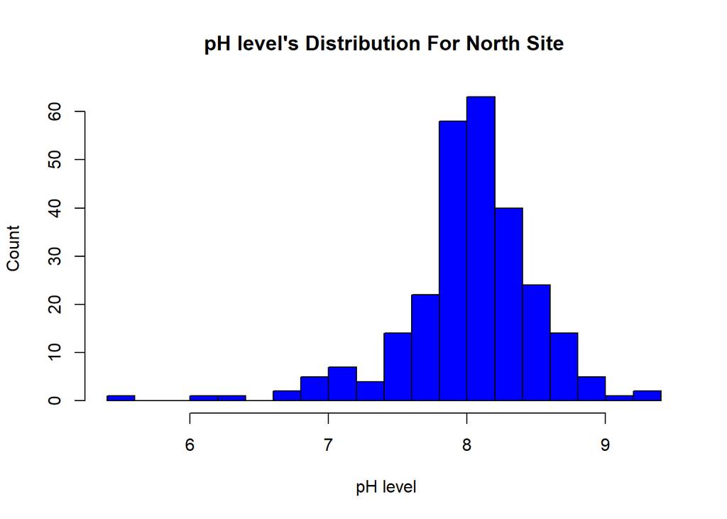

pH level shows normal distribution with the maximum number of samples lying between 7.5 to 8.5.

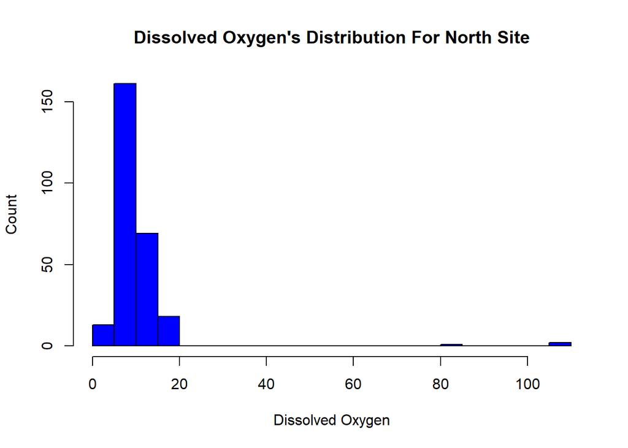

Dissolved Oxygen shows normal distribution with the maximum number of samples lying between 0 to 18.

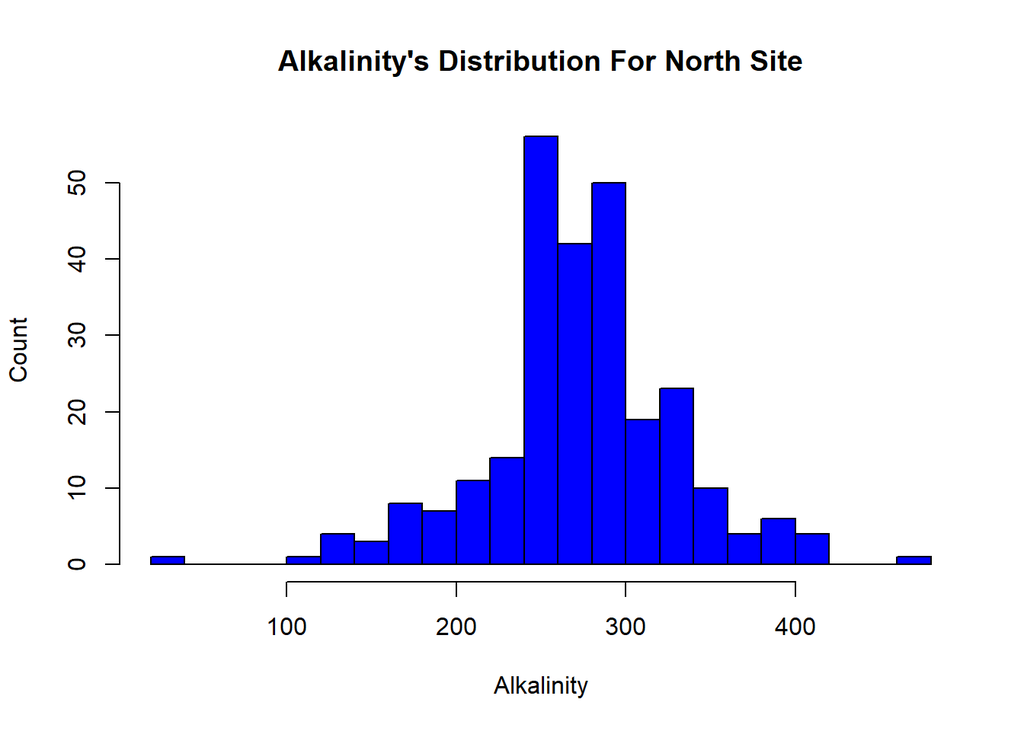

Alkalinity shows normal distribution with the maximum number of samples lying between 220 to 330.

### Box Plot for variables Dissolved Oxygen and Alkalinity with and without outliers for North Site.

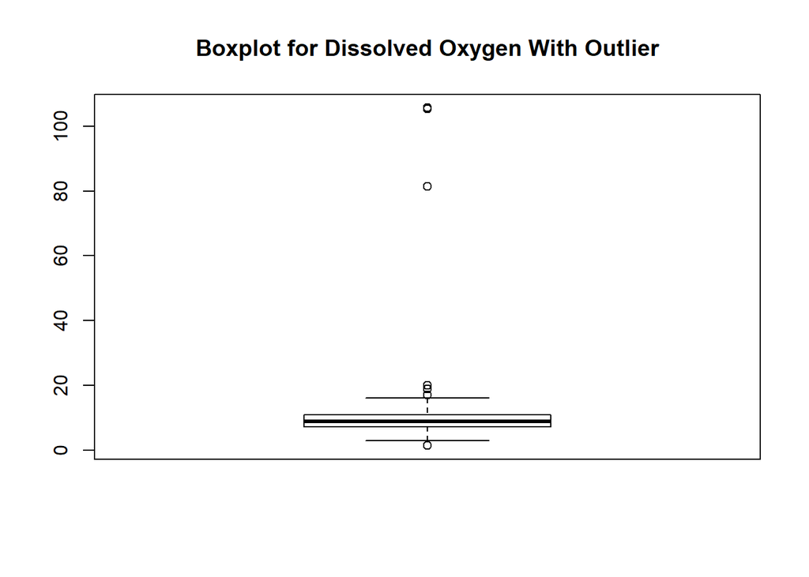

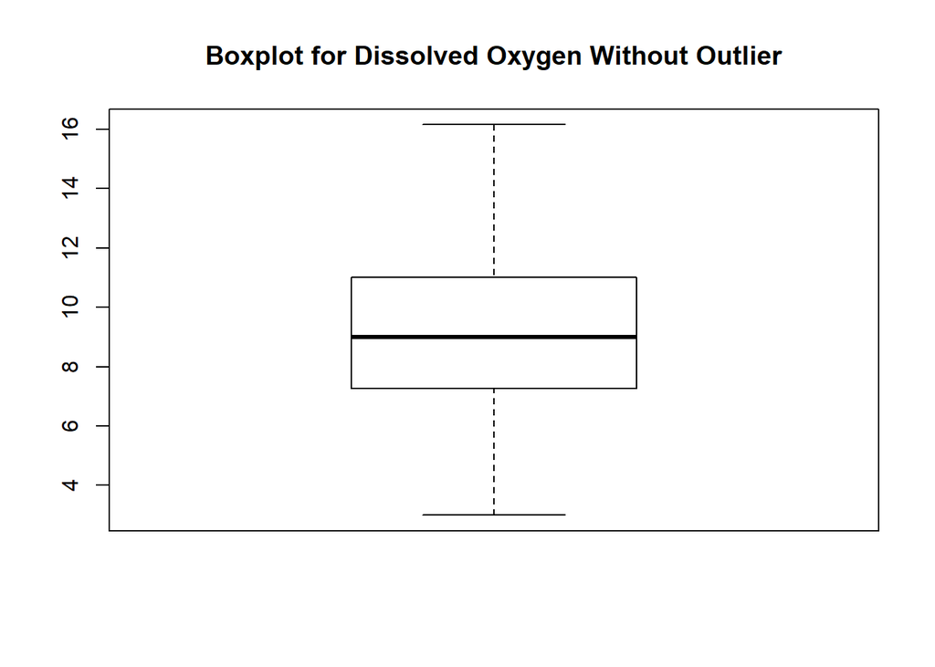

From the above two graphs, we conclude that the samples of Dissolved Oxygen contain Outliers.

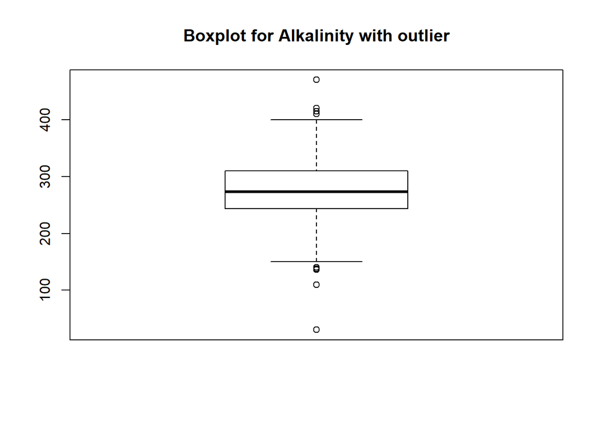

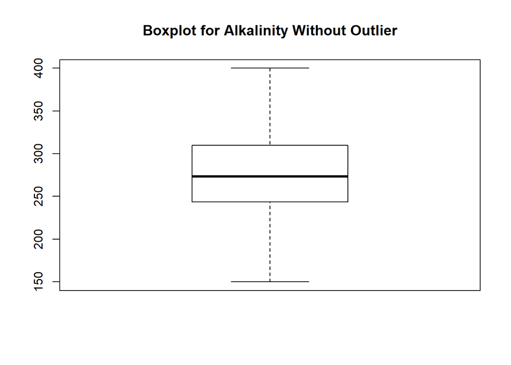

From the above two graphs, we conclude that the samples of Alkalinity contain Outliers.

## Analysis By Creating R Plots for pH level of water with respect to Dissolved Oxygen and Alkalinity For West Site.

For the below plots, a new cleaned dataset **“West Site.csv”** was created. The dataset consists of data from 2013-2017 and observations belonging only the for West site.

We would look at distribution for the variables Dissolved Oxygen, Alkanility and pH level of water for West site.

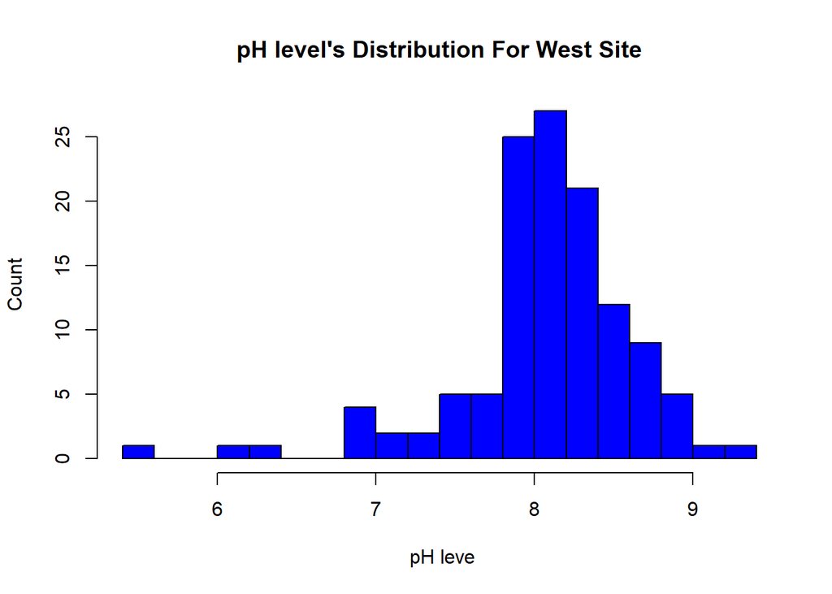

pH level shows normal distrubution with the maximum number of samples lying between 7.5 to 9.

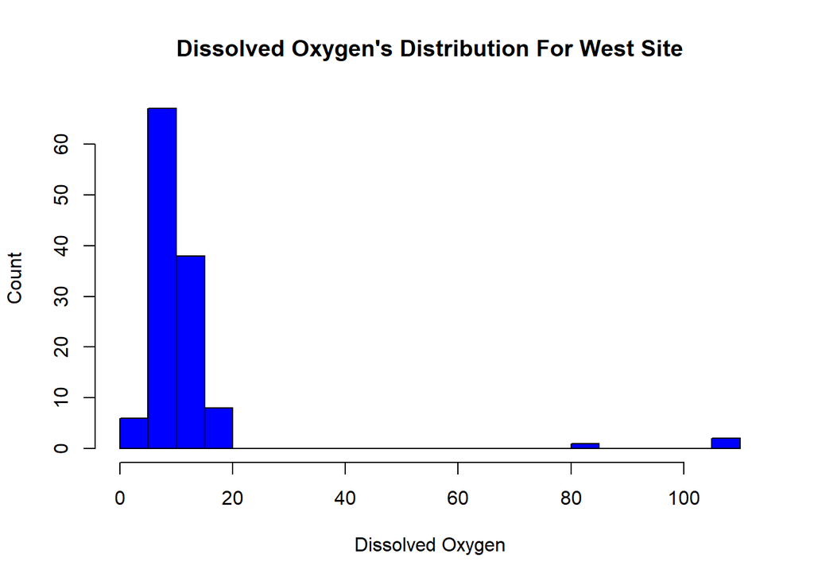

Dissolved Oxygen shows normal distribution with the maximum number of samples lying between 0 to 19.5.

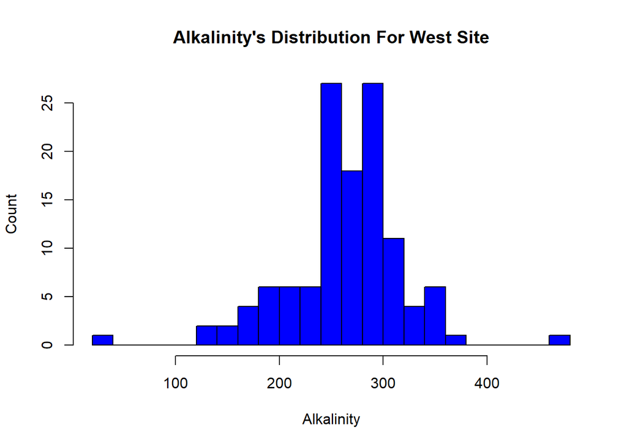

Alkalinity shows normal distribution with the maximum number of samples lying between 230 to 320.

### Box Plot for variables Dissolved Oxygen and Alkalinity with and without outliers for West Site

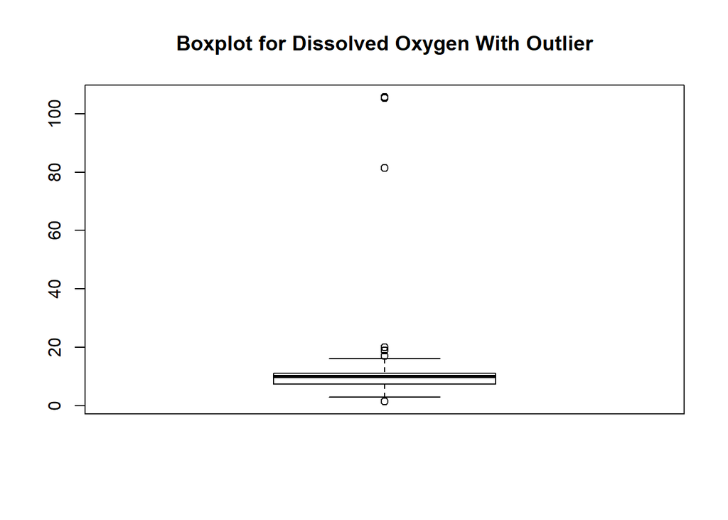

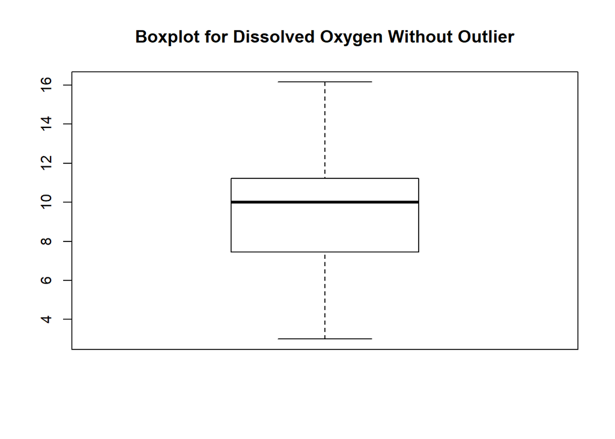

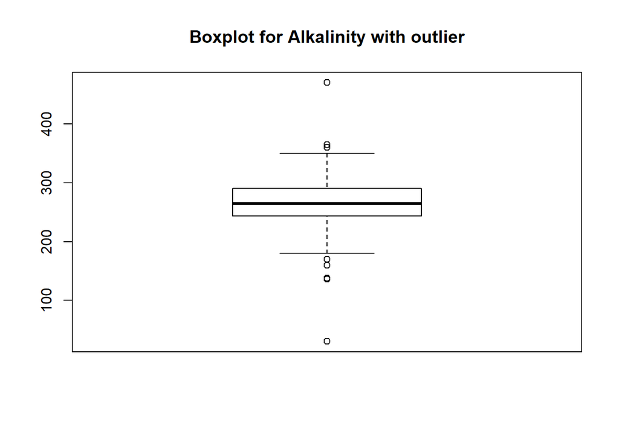

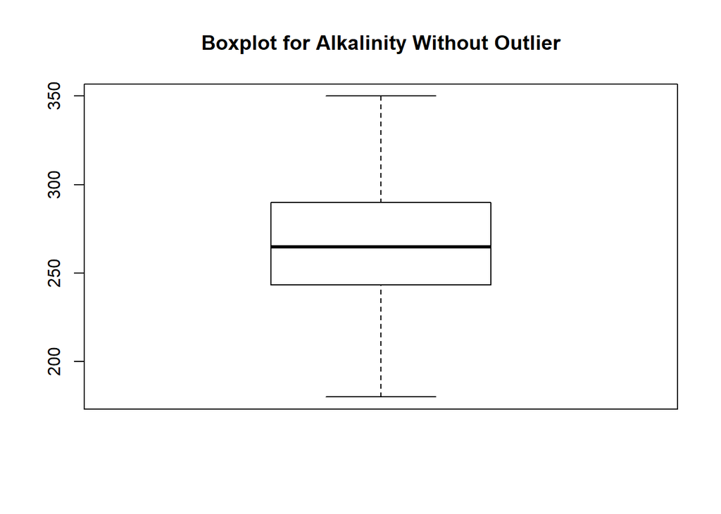

From the above two graphs, we conclude that the samples of Alkalinity contain Outliers.

## Ggplot of variable pH for North and West sites

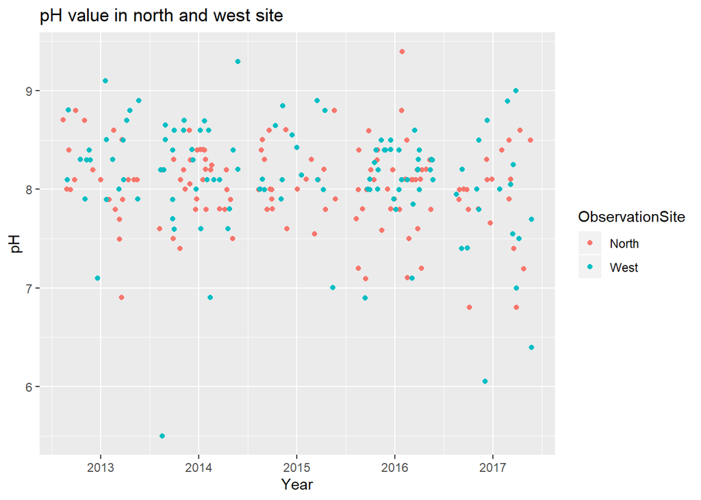

## Ggplot of variable E coli for North and West sites

We are trying to see the differences in Ecoli value on the north and west sites. As we know that Ecoli value in water should not be exceeded 575 colonies per 100 ml of water. We can see from our graph that the amount of bacteria E-coli was more than the standard value in the west site compare to the north site.

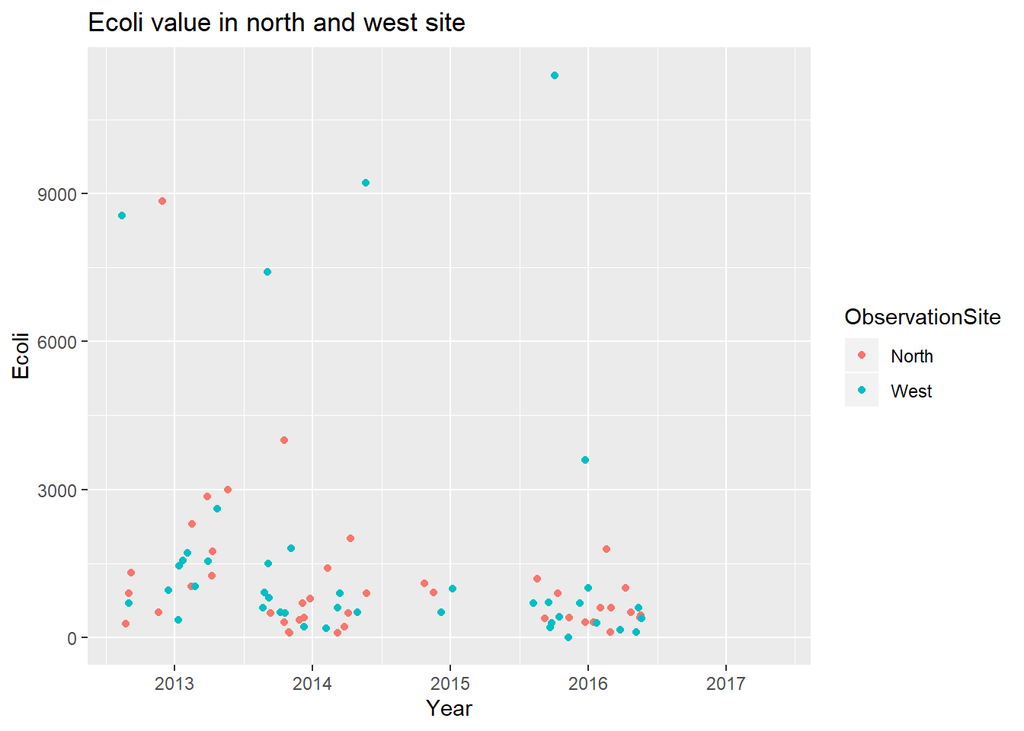